# Spit Chain: Social Network Analysis in Nonhuman Primates

Sam, Nicole, Jess, Bhavya, Brooke

2023-10-29

[figure not shown]

# What is a social network?

A social network analysis describes all the individuals in a group AND all the links between them. The photo above shows a social network from the show The L Word. These are all individuals who have romantic and sexual connections to each other.

[figure not shown]

## What do social network analyses tell us?

Social network analysis includes the theory, methods, and applications of social networks.  
In this vignette, you will learn **(1)** how to prepare social network data for analysis and **(2)** how to perform quadratic assignment procedures to assess correlations between social networks (response variables) and factors that may influence networks (predictor variables).  
A network analysis (as opposed to a non-network analysis) will reveal information about the group as a whole, as opposed to the individual. Non-network analysis would only look at Shane’s romantic connections alone, but social network analysis can tell us Shane’s romantic connections in relation to Alice’s and Lauren’s, etc. It could also reveal group level characteristics that don’t exist for individuals. We are looking at the patterns of relationships between individuals. An edge is as much a network-object as a node is.

## Terms to know

- **Nodes**: the individuals in the social network
- **Edges**: the relationships between individuals in a network

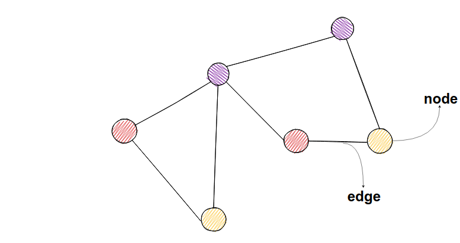

- **Directionality**: some social networks will have a relationship that goes in one direction (e.g., Bonobo A grooms Bonobo B. Other relationships won’t have directionality, such as friendship). *Directionality is relevant for understanding transactional or rank-based relationships.*
- **Edge weight**: the strength of the relationship between individuals, which may differ between individuals within social networks (e.g., if A gives B money, we might be interested the amount they gave. This value is the edge’s weight)

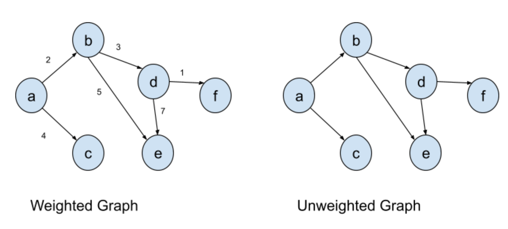

By the end of this module, you should be able to answer the following questions about social networks in R:  
1) *How are individuals connected in a group?*  
2) *How can we test the extent to which specific factors influence whether individuals in a group are connected?*  
3) *What are some ways we can use social network analysis to look at non-human primates and their complex social lives?*  
4) *How do networks change over time?*

To accomplish this, we will use social network datasets from nonhuman primates!

# Installing packages

Here are the packages we’ll be using:

```r
library(statnet)
```

```r
library(igraph)
library(intergraph)
```

{igraph} and {statnet} are two of the most commonly used packages for social network analyses. Both include built-in functions that can plot networks and answer almost every beginner-level question about a given network. However, there may be some functions that are present in one package but not the other (or just work better). So, {intergraph} is another useful package that helps users transition between {igraph} and {statnet}.

# Understanding the structure of social network data

## Loading data

Let’s start by loading our data. We’ll start with a dataset about bonobos and their grooming partners and GG rubbing partners.

```r
library(curl)
f <- curl("https://raw.githubusercontent.com/nmerullo/AN588_BonoboSpitChain/main/AnzaEtAl_2021_ggr_weighted.csv")
bonobo_ggr_edgelist <- read.csv(f, header = TRUE, sep = ",")
head(bonobo_ggr_edgelist) # this is data about their GG rubbing interactions
```

```
##   actor receiver GGR.Weight
## 1    ln       ky          4
## 2     h        j         20
## 3     j        h          4
## 4    ky       lc         15
## 5    lc       ky         20
## 6    lc       ln         31
```

```r
q <- curl("https://raw.githubusercontent.com/nmerullo/AN588_BonoboSpitChain/main/AnzaEtAl_2021_grooming_weighted.csv")
bonobo_groom_edgelist <- read.csv(q, header = TRUE, sep = ",")
head(bonobo_groom_edgelist) # this is data about their grooming interactions
```

```
##   actor receiver weight
## 1     j       li      1
## 2    li        h      3
## 3     h        j      6
## 4     j        h      3
## 5     h       li      2
## 6    ln       dn      8
```

```r
j <- curl("https://raw.githubusercontent.com/nmerullo/AN588_BonoboSpitChain/main/AnzaEtAl_2021_attributes.csv")
bonobo_attribute <- read.csv(j, header = TRUE, sep = ",")
head(bonobo_attribute)
```

```
##   actor rank age
## 1    ln 3.42   9
## 2     h 3.42  31
## 3     j 6.20  24
## 4    ky 4.66  11
## 5    lc 4.11   9
## 6    dn 5.57  44
```

## Setting up social network data

How we set-up and manage the social network data can impact the ease with which we navigate our social network analysis. Based on how many individuals there are, whether we know any of their properties (age, sex, etc), and information about the edges themselves (directionality, edge-weights, etc), we can store and input data either as a matrix or an edgelist.

### Adjacency matrix

A matrix used for social network analysis is called a **sociomatrix** or an **adjacency matrix**. They are square matrices. For directed networks, rows indicate the starting node, and columns indicate the receiving node. Undirected networks are symmetric matrices around the diagonal. For un-weighted networks, the cells contain a 1, for the presence of an edge and a 0 for the absence of an edge between individuals. For weighted networks, the cells can contain the edge-weights instead of 1s and 0s.

### Edge list

Alternatively, we can also represent network data as a columned list, called an **edge list**. Each row of the list represents one edge (one relationship between individuals). In directed data, the first column names the sender of the edge and the second column names the receiver. In undirected data, it does not matter which node is listed first. For weighted data, a third column contains a numeric value for each tie.

**Is our bonobo dataset structured as an edge list or adjacency matrix?**

### Node-Level Variables

To include variables that describe your nodes (age, rank, sex, etc), it is good practice to load in a separate file. This data frame must include one column of the node IDs using the exact same IDs used in the adjacency matrix or edge list. All other variables should then be included in additional columns.

```r
head(bonobo_attribute)
```

```
##   actor rank age
## 1    ln 3.42   9
## 2     h 3.42  31
## 3     j 6.20  24
## 4    ky 4.66  11
## 5    lc 4.11   9
## 6    dn 5.57  44
```

Create the network objects and add the node attributes to the objects.

```r
bonobo_ggr_net <- as.network.data.frame(bonobo_ggr_edgelist) #Creates a network of G-G rubbing
bonobo_groom_net<-as.network.data.frame(bonobo_groom_edgelist) #Creates a network of grooming

bonobo_ggr_net %v% "rank" <- bonobo_attribute$rank #adds a rank variable to the G-G rubbing network
bonobo_ggr_net %v% "age" <- bonobo_attribute$age #adds an age variable to the G-G rubbing network
bonobo_groom_net %v% "rank" <- bonobo_attribute$rank #adds a rank variable to the grooming network
bonobo_groom_net %v% "age" <- bonobo_attribute$age #adds an age variable to the grooming network
```

## Visualizing social network data

We can visualize social networks by creating network objects with {statnet}. Note the arrows indicating directionality!

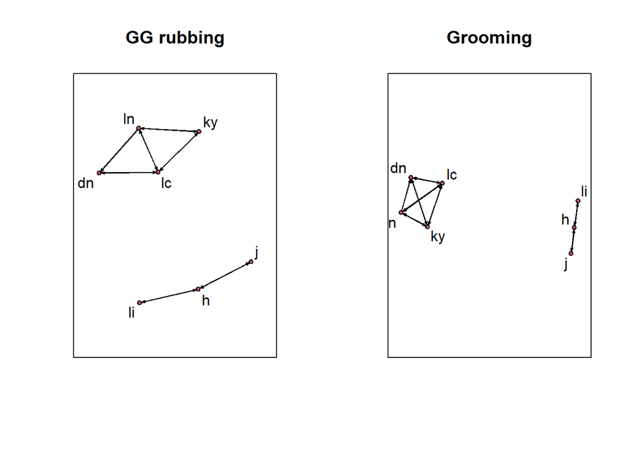

```r
par(mfrow = c(1, 2))
plot(bonobo_ggr_net, label = "vertex.names", main="GG rubbing")
box(col = "black")
plot(bonobo_groom_net, label = "vertex.names", main="Grooming")
box(col = "black")
```